# R Agent Based Model for Infectious Diesease Tutorial

Jasper Zhang

- Jasper Zhang, MSc
- Petros Pechlivanoglou, PhD

Please acknowledge our work. See details to cite below.

Change `eval` to `TRUE` if you want to knit this document.

# 01 Load packages

```r
if (!require('pacman')) install.packages('pacman'); library(pacman)
# load (install if required) packages from CRAN
p_load("devtools", "dplyr", "scales", "ellipse", "ggplot2", "lazyeval", "igraph", "truncnorm", "ggraph", "reshape2", "knitr", "markdown", "stringr", "dampack", "matrixStats")
# load (install if required) packages from GitHub
# install_github("DARTH-git/darthtools", force = TRUE) # Uncomment if there is a newer version
p_load_gh("DARTH-git/darthtools")
```

# 02 Load functions

```r
# No functions needed
```

# 03 Model input

## 03.1 Define model input parameters

```r
## General setup
set.seed(1)                                      # set the seed
n_cycles        <- 100                           # number of cycles
n_i             <- 10000                         # number of individuals

# quarantine period
q_maxtime                   <- 14

# incubation period
latentperiod                <- 4 # time from receiving virus to being infectious

# detect period
detect_time                 <- 9 # time from receiving virus to be detected, 5 days after being infectious

# days to recover from being infected
recover_days                <- 14

# the 5 health states of the model:
v_names_states  <- c("S",   # Susceptble
                     "SQ",  # Susceptble quarantine
                     "I",   # Infected
                     "IQ",  # Infected quarantine
                     "R")   # Recovered

v_names_cycles  <- paste("cycle", 0:n_cycles)    # cycle names
n_states        <- length(v_names_states)        # number of health states


#not in
`%!in%`                      <- Negate(`%in%`)


#define groups of states

ending_states                <- c("R")

infect_states                <- c("I","IQ")

infect_states_iso            <- c("IQ")

all_infect_states            <- c(infect_states,infect_states_iso)

iso_states                   <- c("IR","IQ")

sus_states                   <- c("S","SQ")



#### Deterministic analysis ####

#Transition probabilities

#infection probabilities vary by location
# community

p_TransmitCommunity   <- 0.07683164968542 #household aldult

# atwork \ university
p_TransmitWork        <- 0.0220595686685414
```

# 04 Sample individual level characteristics

## 04.1 Static characteristics

```r
create_abmpop <- function(npop, seed_ratio) {
  # Initialize a population dataframe for an agent-based model

  # Arguments:
  # npop: number of people in the population
  # seed_ratio: proportion of people infected at the beginning of the simulation

  # Returns:
  # A dataframe representing the initialized population

  # Create agent matrix
  agents <- data.frame(
    ptid = 1:npop,  # Assign individual IDs
    Sex = sample(x = c("Female", "Male"), prob = c(0.5, 0.5), size = npop, replace = TRUE),  # Random gender assignment
    Age = round(rnorm(npop, mean=19, sd=15), digits = 0),  # Age drawn from a normal distribution
    wid = 0,  # Workplace ID
    fid = 0,  # Family ID
    qtime = 0,  # Quarantine time clock
    time = 0,   # Total quarantine time
    state = "S" # Initial state of everyone is healthy ("S")
  )

  # Determine the initial number of 'S' (susceptible) and 'I' (infected) agents based on seed_ratio
  n_S <- round((1 - seed_ratio) * npop)
  n_I <- npop - n_S

  # Randomly assign initial states to agents
  agents$state <- sample(c(rep("S", n_S), rep("I", n_I)))

  # Ensure Age variable has only positive values
  agents$Age <- agents$Age + abs(min(agents$Age))

  # Define family structure and IDs
  family_size <- c(1, 2, 3, 4)
  p_family_size <- family_size / sum(family_size)
  fam_num <- floor(npop * p_family_size / family_size)[1]
  fam_id <- c(
    rep(1:fam_num, each = family_size[1]),
    rep((fam_num + 1):(fam_num*2), each = family_size[2]),
    rep((fam_num*2 + 1):(fam_num*3), each = family_size[3]),
    rep((fam_num*3 + 1):(fam_num*4), each = family_size[4])
  )
  fam_id <- c(fam_id, rep((max(fam_id) + 1), each = (npop - length(fam_id))))
  agents$fid <- fam_id

  # Define workplace structure and IDs
  work_size <- c(5, 7, 8)
  p_work_size <- work_size / sum(work_size)
  work_num <- floor(npop * p_work_size / work_size)[1]
  work_id <- c(
    rep(1:work_num, each = work_size[1]),
    rep((work_num + 1):(work_num*2), each = work_size[2]),
    rep((work_num*2 + 1):(work_num*3), each = work_size[3])
  )
  work_id <- sample(c(work_id, rep((max(work_id) + 1), each = (npop - length(work_id)))))
  agents$wid <- work_id

  # Initialize other agent attributes
  agents <- agents %>%
    mutate(
      expl = 0,  # Exposure level
      contact_num = 0,  # Number of contacts in a day
      contact_max = 0,  # Maximum number of contacts
      contact_type = 0,  # Contact type
      atwork = 1,  # Indicates if the agent is at work
      v_Ts = 0,  # Time since being infected
      detect_time = detect_time,
      new_detection = 0
    )

  # Set the number of contacts at work based on workplace size
  work_in_sample <- agents$ptid[which(agents$atwork == TRUE)]
  work_size <- table(agents[work_in_sample, ]$wid)
  work_info <- data.frame(wid = as.numeric(as.character(names(work_size))), wsize = as.numeric(as.matrix(work_size)))
  work_place_size <- merge(agents[work_in_sample, ], work_info, by = "wid") %>%
    arrange(ptid) %>%
    rowwise() %>%
    mutate(contact_num = sample(0:(wsize - 1), 1))  # Randomly assign contact number

  agents$contact_num[work_in_sample] <- work_place_size$contact_num
  agents$contact_max[work_in_sample] <- work_place_size$wsize - 1

  return(agents)
}
```

## 04.2 Dynamic characteristics

```r
# Specify the initial health state of the individuals
# everyone begins in the healthy state (in this example)
v_M_init  <- rep("S", times = n_i)
v_n_cycles_s_init <- rep(0, n_i)  # a vector with the time of being sick at the start of the model
```

## 04.3 Create a dataframe with the individual characteristics

```r
# create a data frame with each individual's
# ID number, treatment effect modifier, age and initial time in sick state

# NOTE: we use n_cycles_s for the number of times being sick, we start the data frame with the initial "history" of time being sick by saving v_Ts_init. However, during the simulation this value is updated and therefore called numer of times being sick.
#head(df_X) # print the first rows of the dataframe

df_X <- create_abmpop(n_i,0.1)
```

# 05 Define Simulation Functions

## 05.1 Probability function

The `Probs` function updates the transition probabilities of every cycle is shown below.

```r
infect_prob <- function(prob,exposure) {
  # Arguments:
  # prob:     the probability of infection in one time contact
  # exposure: the time of being exposed to infectious individuals
  # Returns:
  # the probability of being infected based on certain exposure time
  return(1 - (1 - prob) ^ (exposure))   # 1 - prob is the prob of being safe,
  # 1 minus the prob of always being safe is the prob of getting infection
}

Probs <- function(M_t, df_X, v_Ts) {
  # Arguments:
  # M_t:  health state occupied at cycle t (character variable)
  # df_X: data frame with individual characteristics data
  # v_Ts: vector with the duration of being infected
  # Returns:
  # transition probabilities for that cycle

  # create matrix of state transition probabilities
  m_p_t           <- matrix(0, nrow = n_states, ncol = n_i)
  # give the state names to the rows
  rownames(m_p_t) <-  v_names_states

  #Calculate the probability of being infected for susceptible people
  sus <- df_X[df_X$state == "S",] #identify those susceptible

  sus_prob_home = p_TransmitCommunity

  sus_prob = rep(0,nrow(sus))
  at_work = sus$contact_type == 1
  if(sum(at_work) > 0){
    work_infect = infect_prob(p_TransmitWork,sus[at_work,]$expl)
    sus_prob[sus$expl > 0 & sus$contact_type == 1] = work_infect
  }
  p_Sus_Inf <- (1- ((1- sus_prob_home) * (1 - sus_prob))) # 1 minus the prob of being safe all day


  #Calculate the probability of being infected for susceptible quarantine
  sus_Q <- df_X[df_X$state == "SQ",] #identify those susceptible

  #check exposure number
  sus_prob_home_Q  <- rep(p_TransmitCommunity, nrow(sus_Q))


  # the 5 health states of the model:
  v_names_states  <- c("S",   # Susceptble
                      "SQ",  # Susceptble quarantine
                       "I",   # Infected
                      "IQ",  # Infected quarantine
                       "R")   # Recovered


  #susceptible
  m_p_t["S"                                   , M_t == "S"]                    <- 1 - p_Sus_Inf
  m_p_t["SQ"                                  , M_t == "S"]                    <- 0
  m_p_t["I"                                   , M_t == "S"]                    <- p_Sus_Inf
  m_p_t["IQ"                                  , M_t == "S"]                    <- 0
  m_p_t["R"                                   , M_t == "S"]                    <- 0


  #susceptible quarantine
  m_p_t["S"                                   , M_t == "SQ"]                   <- 1 -  sus_prob_home_Q
  m_p_t["SQ"                                  , M_t == "SQ"]                   <- 0
  m_p_t["I"                                   , M_t == "SQ"]                   <- 0
  m_p_t["IQ"                                  , M_t == "SQ"]                   <- sus_prob_home_Q
  m_p_t["R"                                   , M_t == "SQ"]                   <- 0

  #infected
  m_p_t["S"                                   , M_t == "I" ]                   <- 0
  m_p_t["SQ"                                  , M_t == "I" ]                   <- 0
  m_p_t["I"                                   , M_t == "I"]                    <- 1
  m_p_t["IQ"                                  , M_t == "I"]                    <- 0
  m_p_t["R"                                   , M_t == "I"]                    <- 0

  #infected quarantine
  m_p_t["S"                                   , M_t == "IQ"]                   <- 0
  m_p_t["SQ"                                  , M_t == "IQ"]                   <- 0
  m_p_t["I"                                   , M_t == "IQ"]                   <- 0
  m_p_t["IQ"                                  , M_t == "IQ"]                   <- 1
  m_p_t["R"                                   , M_t == "IQ"]                   <- 0


  #recover ending state
  m_p_t["S"                                   , M_t == "R"]                    <- 0
  m_p_t["SQ"                                  , M_t == "R"]                    <- 0
  m_p_t["I"                                   , M_t == "R"]                    <- 0
  m_p_t["IQ"                                  , M_t == "R"]                    <- 0
  m_p_t["R"                                   , M_t == "R"]                    <- 1


  return(t(m_p_t))
}
```

## 05.1 Quanrantine Function

```r
#Quarantine_Check can update the quarantine clock at current time cycle
Quarantine_Check <- function(pop, pre_state){
  # Arguments:
  # pop: population dataframe of current time cycle t
  # pre_state: states at previously cycle t-1
  # Returns:
  # new population dataframe with updated states

  # Step1: find people in different quarantine conditions

  # People in quarantine:
  # condition 1: reset quarantine clock for those who become infected or have close contact with infected people during quarantine
  new_infected_in_Q          = which(pop$state %in% infect_states_iso & pre_state == "SQ") #got infected in quarantine

  reset_family               = unique(pop$fid[new_infected_in_Q])
  reset_people               = pop$fid %in% reset_family #find all the people who had expose in family quarantine


  # condition 2: find people are going to be released from quarantine
  # check if quarantine clock hit q_maxtime
  full_q                     = pop$qtime == q_maxtime & !reset_people & pop$state %!in% ending_states

  #find susceptible people and infected people who meet quarantine time
  sus_full_q                 = full_q & pop$state == "SQ"
  inf_full_q                 = full_q & pop$state %in% infect_states_iso

  # condition 3: find people who stay in quarantine and the quarantine clock has to be incremented.
  else_q                     = (pop$qtime < q_maxtime & pop$qtime >0) & !reset_people & pop$state %!in% ending_states

  # Other people:
  # condition 4: find newly infected people entering quarantine NOTE: people enter quarantine by detection
  new_infected               = which(pop$state %in% iso_states & pop$qtime == 0) #new infected generated from infected

  # condition q_maxtime: find newly infected people's dependencies in families and workpalces
  new_infected_family        = unique(pop$fid[new_infected]) #families have newly infected in quarantine cases

  #new_infected_work= unique(pop$wid[new_infected]) #workplaces have newly infected in quarantine cases #comment out if same workplace contact don't need to be put in quarantine

  new_qurantine              = (((pop$fid %in% new_infected_family & pop$qtime == 0) | #(pop$wid %in% new_infected_work & pop$qtime == 0) |
                                   (pop$fid %in% reset_family)) & (pop$state %!in% ending_states) & (!(pop$essential == 1 & pop$getspsl == 0))  ) #people whose quarantine clocks have to be set to 1 including
  new_qurantine_add = new_qurantine & pop$state %!in% iso_states #find people need to be put in quarantine state


  # Step2: Update quarantine clock
  # set new_quarantine clock to 1
  pop$qtime[new_qurantine]    = 1
  pop$state[new_qurantine_add] = paste(pop$state[new_qurantine_add],"Q",sep = "") #update quarantine states
  pop$time[new_qurantine]     = pop$time[new_qurantine]+1 #increment total quarantine time


  # release people with meet q_maxtime-days quarantine requirement
  # - isolated susceptible people will go to susceptible
  # - infected people will go to recovered
  pop$qtime[full_q]           = 0
  pop$state[sus_full_q]       = "S" #when quarantine ends, state goes back to susceptible
  pop$state[inf_full_q]       = "R" #when quarantine ends, state goes back to recovered

  #increment quarantine clock and total quarantine time for everyone else in quarantine
  pop$qtime[else_q]           = pop$qtime[else_q] + 1
  pop$time[else_q]            = pop$time[else_q] + 1
  return (pop)
}
```

## 0.5.1 Exposure at work

```r
# Exposure_Check calculates the exposure of workers at their workplace
work_exposure <- function(pop) {

  # Step1: Initialize and filter worker population
  allpop <- pop                                                                 # Extract entire population data
  worker_list <- pop[pop$atwork == 1,]                                          # Filter workers currently at work

  # Check if there are workers present
  if (sum(pop$atwork == 1) > 0) {
    select_pop <- allpop[pop$atwork == 1,]
    expl_list <- select_pop$expl
    infectious <- select_pop$state %in% infect_states                           # Identify infectious individuals
    wid_list <- select_pop$wid                                                  # List of workplace IDs
    out_of_iso <- select_pop$state %!in% iso_states                             # Workers out of isolation
    ptid_list <- select_pop$ptid[out_of_iso & select_pop$state == "S"]          # Susceptible workers out of isolation

    # Step2: Build the workplace table
    workplacetable <- data.frame(table(wid_list[select_pop$atwork == 1]))
    names(workplacetable) <- c("wid", "wsize")

    inf_worker <- select_pop[infectious,]                                       # Filter infectious workers
    inf_workplace <- inf_worker$wid                                             # List of workplaces with infectious workers

    # Check if there are infectious workers present
    if (nrow(inf_worker) > 0) {
      contact <- c()

      # Step3: Identify contacts for infectious workers
      for (i in 1:nrow(inf_worker)) {
        select_worker <- inf_worker[i,]
        workplaceptid <- select_pop[select_pop$wid == select_worker$wid,]$ptid  # Fetch workers at the same workplace
        to_contact <- workplaceptid[!workplaceptid %in% select_worker$ptid]     # Exclude the current worker

        # Determine contacts based on the contact number
        if (length(to_contact) > 1) {
          new_contact <- sample(to_contact, min(length(to_contact), select_worker$contact_num))
          contact <- c(contact, new_contact)
        } else if (length(to_contact) == 1) {
          contact <- c(contact, to_contact)
        }
      }

      # Step4: Build the contact table
      if (length(contact) != 0) {
        contact_table <- data.frame(table(contact))
        names(contact_table) <- c("ptid", "expl")

        # Convert to numeric types
        contact_table$ptid <- as.numeric(as.character(contact_table$ptid))
        contact_table$expl <- as.numeric(as.character(contact_table$expl))

        # Update exposure levels
        expl_list[select_pop$ptid %in% contact_table$ptid] <- expl_list[select_pop$ptid %in% contact_table$ptid] + contact_table$expl
        allpop[allpop$ptid %in% contact_table$ptid,]$contact_type <- 3
      }
    }

    # Update the main population dataset
    allpop[pop$atwork == 1,]$expl <- expl_list
  }

  return(allpop)
}
```

## 05.2 Detection function

The `Detection` function detec infected people

```r
Detection <- function(pop, v_TS){

  # Detect individuals infected for 9 days
  detected_individuals = (v_TS == pop$detect_time) & pop$state %!in% ending_states

  # Update the new detection count in the population data
  pop$new_detection = sum(detected_individuals)

  # Update state of newly detected individuals not in isolation states to include quarantine ("Q")
  new_iso = detected_individuals & pop$state %!in% iso_states
  pop$state[new_iso] = paste(pop$state[new_iso], "Q", sep = "")

  return(pop)
}
```

## 05.4 Microsimulation function

Below we develop the microsimulation function that allows the model to be run.

```r
# `MicroSim` is a microsimulation function to model individual-level disease progression and transmission.
MicroSim <- function(df_X, seed = 1, n_cycles = 10) {

  # Arguments:
  # df_X: A data frame containing individual-level data.
  # seed: Seed for the random number generator; default is 1.
  # n_cycles: Number of cycles or iterations to simulate; default is 10.

  # Ensures reproducibility of results.
  set.seed(seed)

  # Determine the number of individuals in the dataset.
  n_i = nrow(df_X)

  # Initialization of matrices to store:
  # m_M: health state information over time for every individual.
  # m_vts: track the number of days since an individual got infected.
  # m_expl: track exposure levels for individuals.
  # Each matrix has rows corresponding to individuals and columns corresponding to days.

  m_M <- matrix(nrow = n_i, ncol = n_cycles + 1,
                dimnames = list(paste("ind", 1:n_i, sep = " "),
                                paste("cycle", 0:n_cycles, sep = " ")))
  m_vts <- matrix(nrow = n_i, ncol = n_cycles + 1,
                  dimnames = list(paste("ind", 1:n_i, sep = " "),
                                  paste("cycle", 0:n_cycles, sep = " ")))
  m_expl <- matrix(nrow = n_i, ncol = n_cycles,
                   dimnames = list(paste("ind", 1:n_i, sep = " "),
                                   paste("cycle", 1:n_cycles, sep = " ")))

  # Set initial health state and time since illness onset for each individual.
  m_M[, 1] <- as.character(df_X$state)
  m_vts[,1] <- df_X$v_Ts
  v_Ts <- df_X$v_Ts
  v_inf <- rep(0, n_i)

  # Initialize vectors to store daily counts of total infections, new infections, and detected cases.
  v_total_inf_daily <- rep(0,n_cycles)
  v_new_inf_daily <- rep(0,n_cycles)
  v_detected_daily <- rep(0,n_cycles)

  # Simulation loop for each day.
  for (t in 1:n_cycles) {

    # Reset exposure and contact type levels for each individual.
    df_X$expl <- 0
    df_X$expl_home <- 0
    df_X$contact_type <- 0

    # Calculate exposure at work for each individual.
    df_X <- work_exposure(df_X)
    m_expl[,t] <- df_X$expl

    # Calculate transition probabilities based on current health state and exposure.
    m_P <- Probs(m_M[, t], df_X, v_Ts)

    # Validate transition probabilities.
    check_transition_probability(m_P, verbose = TRUE)
    check_sum_of_transition_array(m_P, n_rows = n_i, n_cycles = n_cycles, verbose = TRUE)

    # Generate new health states based on the calculated transition probabilities.
    prob_new_state = samplev(m_P)
    df_X$state = prob_new_state
    df_X = Detection(df_X,v_Ts)
    prob_new_state = df_X$state

    # Update vectors with new infection, total infection, and detection counts.
    v_detected_daily[t] = df_X$new_detection[1]
    v_total_inf_daily[t] = sum(prob_new_state %in% all_infect_states)
    v_new_inf_daily[t] = sum((m_M[, t] %in% sus_states   & prob_new_state %in% all_infect_states ))

    # Update quarantine status based on previous day's state and current state.
    df_X = Quarantine_Check(df_X,m_M[, t])
    qc_state = df_X$state

    # Update the time since illness onset for next day.
    v_Ts <- if_else(qc_state %in% all_infect_states, v_Ts + 1, 0)
    m_vts[,t + 1] = v_Ts

    # Update individuals who have reached recovery time to 'R' state.
    v_go_to_recover <- if_else(v_Ts >= recover_days, TRUE, FALSE)
    df_X$state[v_go_to_recover] = "R"

    # Store current state for each individual for the next day.
    m_M[, t + 1] <- df_X$state

    # Display simulation progress at every 10% completion.
    if(t/(n_cycles/10) == round(t/(n_cycles/10), 0)) {
      cat('\r', paste(t/n_cycles * 100, "% done", sep = " "))
    }
  }

  # Store results from the simulation in a list.
  results <- list(m_M = m_M, pop = df_X, v_new_inf_daily = v_new_inf_daily,
                  v_total_inf_daily = v_total_inf_daily, v_detected_daily = v_detected_daily)

  # Return the results.
  return(results)

} # End of `MicroSim` function
```

## 06 Run Microsimulation

```r
# 06 Run Microsimulation
# By specifying all the arguments in the `MicroSim()` the simulation can be started
# Run the simulation model
outcomes <- MicroSim(df_X = df_X, seed = 1,n_cycles = n_cycles)
```

# 07 Visualize results to be updated

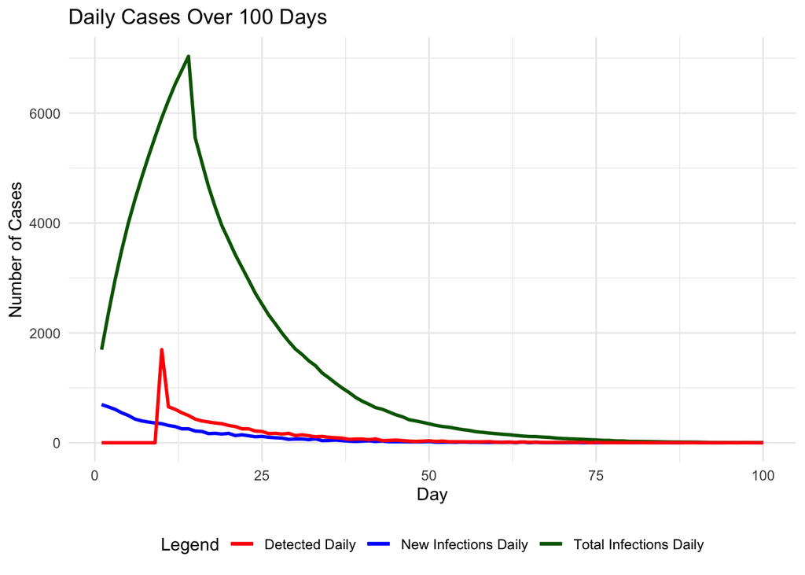

```r
# First, we'll need the ggplot2 library to create the visualizations.
library(ggplot2)

# -------------------------------------
# Step 1: Data Preparation
# -------------------------------------

# Create a data frame to hold the results for visualization.
# Here, we take the number of cycles (days) and the respective outcomes for daily new infections,
# cumulative infections, and daily detections.
df <- data.frame(
  day = 1:n_cycles,                             # Days from 1 to the end of the simulation
  new_inf_daily = outcomes$v_new_inf_daily,     # Daily new infections
  total_inf_daily = outcomes$v_total_inf_daily, # Cumulative daily infections
  detected_daily = outcomes$v_detected_daily    # Daily detected cases
)

# -------------------------------------
# Step 2: Data Visualization
# -------------------------------------

# Using ggplot, we'll plot the daily new infections, cumulative infections, and detected cases.
p <- ggplot(df, aes(x = day)) +                 # Define the x-axis as the 'day'

  # Plot daily new infections
  geom_line(aes(y = new_inf_daily, color = "New Infections Daily"), size = 1) +

  # Plot cumulative infections
  geom_line(aes(y = total_inf_daily, color = "Total Infections Daily"), size = 1) +

  # Plot daily detected cases
  geom_line(aes(y = detected_daily, color = "Detected Daily"), size = 1) +

  # Add labels and title to the plot
  labs(
    title = paste0("Daily Cases Over ",n_cycles," Days"),       # Title of the plot
    x = "Day",                                 # Label for the x-axis
    y = "Number of Cases",                      # Label for the y-axis
    color = "Legend"                            # Legend title
  ) +

  # Customize the colors for each line in the plot
  scale_color_manual(values = c("New Infections Daily" = "blue",
                                "Total Infections Daily" = "darkgreen",
                                "Detected Daily" = "red")) +

  # Use a minimal theme for a clean look
  theme_minimal() +

  # Position the legend at the bottom of the plot
  theme(legend.position = "bottom")

# Display the generated plot
p
```

```r
# -------------------------------------
# Step 3: Save the Visualization
# -------------------------------------

# Save the plot as a PNG image. The DPI determines the resolution, and width and height determine the size.
ggsave("daily_cases_plot.png", p, dpi = 300, width = 10, height = 8, units = "in", device = "png")
```

We kindly request you to add the following Acknowledgement paragraph to your further work where DARTH code formed the basis. We also like to remind you that you can add other sources of reference to this paragraph to acknowledge code you got from others.

# Acknowlegdement

For this work we made use of the template developed by the Decision Analysis in R for Technologies in Health (DARTH) workgroup: http://darthworkgroup.com.

The notation of our code is based on the following provided framework and coding convention: Alarid-Escudero, F., Krijkamp, E., Pechlivanoglou, P. et al. A Need for Change! A Coding Framework for Improving Transparency in Decision Modeling. PharmacoEconomics 37, 1329–1339 (2019). https://doi.org/10.1007/s40273-019-00837-x.

Other work from DARTH can be found on the website: http://darthworkgroup.com/publications/

# Copyright for assignment work

Copyright 2017, THE HOSPITAL FOR SICK CHILDREN AND THE COLLABORATING INSTITUTIONS.All rights reserved in Canada, the United States and worldwide. Copyright, trademarks, trade names and any and all associated intellectual property are exclusively owned by THE HOSPITAL FOR Sick CHILDREN and the collaborating institutions. These materials may be used, reproduced, modified, distributed and adapted with proper attribution.